# Regression Discontinuity Designs

Our first steps with RDD in R

## Welcome

### Introduction!

Welcome to our sixth tutorial for the Statistics II: Statistical Modeling & Causal Inference (with R) course.

During this week’s lecture you were introduced to Regression Discontinuity Designs (RDDs).

In this lab session we will:

- Leverage visualizations with `ggplot2` to explore our discontinuity setups
- Learn how to model our discontinuity setups under different functional forms with `lm()`
- Learn how to model non-parametrically our discontinuity with `rdrobust::rdrobust()`

#### Packages

```r
# These are the libraries we will use today. Make sure to install them in your console in case you have not done so previously.

library(dplyr) # for data wrangling
library(ggplot2) # for creating plots
library(rdrobust) # for rdrobust()
library(rdd) # for McCrary Sorting test
library(readr) # for loading the .csv data
library(modelsummary) # for model output

set.seed(42) # for consistent results

mlda_df <- readr::read_csv("https://raw.githubusercontent.com/seramirezruiz/stats-ii-lab/master/Session%206/data/mlda.csv") # loading data from Mastering Metrics
```

## Example 1. Measuring the effect of the minimum legal drinking age (MLDA) on mortality

> In an effort to address the social and public health problems associated with underage drinking, a group of American college presidents have lobbied states to return the minimum legal drinking age (MLDA) to the Vietnam era threshold of 18. The theory behind this effort (known as the Amethyst Initiative) is that legal drinking at age 18 discourages binge drinking and promotes a culture of mature alcohol consumption. This contrasts with the traditional view that the age-21 MLDA, while a blunt and imperfect tool, reduces youth access to alcohol, thereby preventing some harm. **Angrist and Pischke (2014)**

You have been hired as an outside consultant by Mothers Against Drunk Driving (MADD) to study whether the over-21 drinking minimum in the US helps reduce alcohol consumption by young adults and its harms, or is it just not working. *This example is based on data from Carpenter and Dobkin (2011).*

### Checking visually whether a sharp-RDD makes sense for the analysis

We want to know **whether our threshold is in fact the cut-off for treatment**. In this case, the law is pretty clear: young adults in the US can legally drink at age 21.

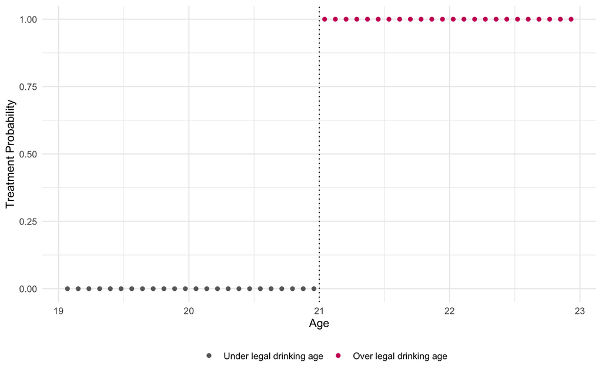

```r
ggplot(mlda_df, aes(x = agecell, # actual age
                    y = treatment, # are they over 21 or not
                    color = factor(treatment))) +
  geom_point() +
  labs(x = "Age",
       y = "Treatment Probability") +
  scale_color_manual(name = " ",
                     values = c("#696969", "#cc0065"),
                     labels = c("Under legal drinking age", "Over legal drinking age")) +
  geom_vline(xintercept = 21, linetype = "dotted") + # NEW GEOM A VERTICAL LINE!
  theme_minimal() +
  theme(legend.position = "bottom")
```

We can see from the graph that at the 21-years-of-age threshold, young adults can legally consume and buy alcohol in the US, which would make age a viable forcing variable for a sharp-RDD set-up.

### Parametric estimation

#### Running our regression models

As was pointed out in the lecture, we must decide on a model that we believe reflects the relationship of our $E(Y_i|\tilde{X}_i)$. We can do this **parametrically** and **non-parametrically**. Let’s start with the **parametric** estimation. In other words, we are going to specify the functional form that we believe the data takes. We will do three models:

- linear, common slope
- linear, different slopes
- non-linear

**Remember that each model corresponds to a particular set of assumptions**

**LET’S LOOK AT A SCATTERPLOT TO GET AN IDEA OF WHAT WE ARE DEALING WITH**

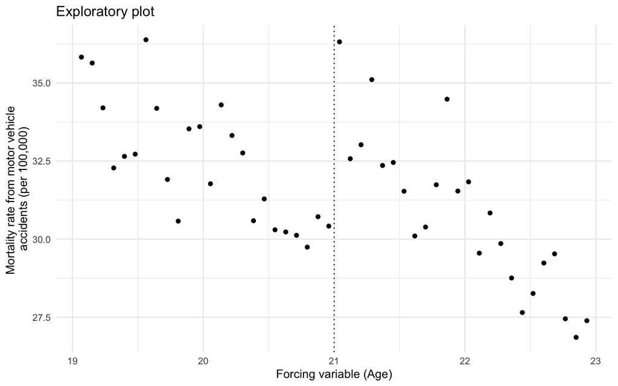

```r
ggplot(mlda_df,
       aes(x = agecell, # age
           y = outcome)) + # mortality rate per 100k accidents
  geom_point() +
  geom_vline(xintercept = 21, linetype = "dotted") +
  labs(title = "Exploratory plot",
       x = "Forcing variable (Age)",
       y = "Mortality rate from motor vehicle \naccidents (per 100,000)") +
  theme_minimal()
```

**NOTE that we have the variable `forcing` in this dataset, which is centered at the cutoff. It is nothing but the variable `age-21`**

##### Linear model with common slopes

Let’s run a linear model with common slopes and plot our results.

**NOTE that the forcing variable in this case (age) is CENTERED at 0 (age 21) and is the distance from age 21 in years, while treatment is just binary over/under 21.**

```r
# running linear model with common slope
linear_common_slope <- lm(outcome ~ treatment + forcing, data = mlda_df)

modelsummary::modelsummary(linear_common_slope,
                           stars = c('*' = .1, '**' = .05, '***' = .01),
                           statistic = 'conf.int',
                           fmt = 2)
```

|  | Model 1 |
| --- | --- |
| (Intercept) | 29.36*** |
|  | [28.49, 30.22] |
| treatment | 4.53*** |
|  | [2.99, 6.08] |
| forcing | −3.15*** |
|  | [−3.83, −2.47] |
| Num.Obs. | 48 |
| R2 | 0.703 |
| R2 Adj. | 0.689 |
| AIC | 168.4 |
| BIC | 175.9 |
| Log.Lik. | −80.225 |
| F | 53.142 |
| RMSE | 1.29 |

**WHAT DO THESE RESULTS TELL US?**

In line with our assumptions for linear models with common slope, we consider that treatment effect $D_i$ does not depend on the forcing $X_i$. We can formalize this model as:
$$E(Y_i|X_i,D_i) = \tilde{\beta_0} + \beta_1 D_i +
\beta_2\tilde{X}_i$$
Hence we can say, that given our $\beta_1$ we can expect 4.53 more deaths from motor vehicle accidents per 100,000 for those who can legally drink. We also see that for every year of age increase, the number of expected deaths per 100,000 decreases by 3.15. (Our $\beta_2 = -3.1488$).

We can graph our results with `ggplot()` by extracting the predicted values of the model to recreate the linear fit:

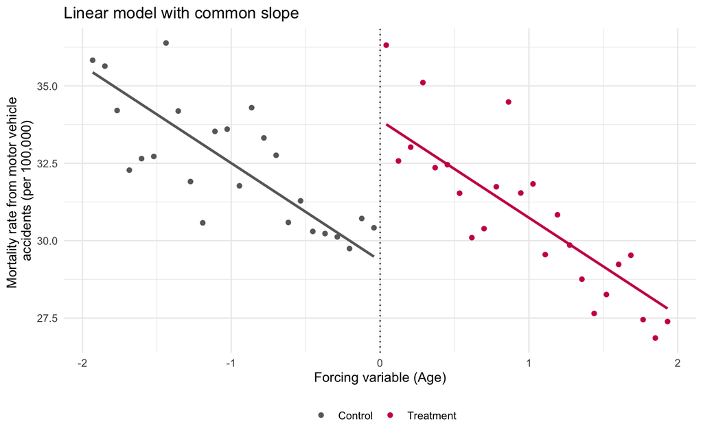

```r
mlda_df$yhat_linear <- predict(linear_common_slope) # we create a new variable containing the predicted mortality rate

linear_plot <- mlda_df %>% # for this plot make sure to put the df outside the ggplot() and pipe it
  ggplot(aes(x = forcing,
             y = yhat_linear, # notice here the predicted y
             col = factor(treatment))) +
  geom_point(aes(x = forcing,
                 y = outcome, # notice here the actual outcome
                 col = factor(treatment))) +
  geom_vline(xintercept = 0, linetype = "dotted") +
  labs(title = "Linear model with common slope",
       x = "Forcing variable (Age)",
       y = "Mortality rate from motor vehicle \naccidents (per 100,000)") +
  geom_line(data = mlda_df[mlda_df$forcing >= 0,],
            color = "#cc0055", # color lines
            linewidth = 1) +
  geom_line(data = mlda_df[mlda_df$forcing < 0,],
            color = "#696969", # color lines
            linewidth = 1) +
  scale_color_manual(name = "",
                     values = c("#696969", "#cc0055"),
                     labels = c("Control", "Treatment")) + #change colors manually of color argument in aes()
  theme_minimal() +
  theme(legend.position = "bottom")

linear_plot
```

##### Linear model with different slopes

Let’s run the linear model to gather the slopes for both groups and plot our results. This is achieved by interacting our treatment and forcing variables.

```r
linear_different_slope <- lm(outcome ~ treatment*forcing, data = mlda_df)

modelsummary::modelsummary(linear_different_slope,
                           stars = c('*' = .1, '**' = .05, '***' = .01),
                           statistic = 'conf.int',
                           fmt = 2)
```

|  | Model 1 |
| --- | --- |
| (Intercept) | 29.93*** |
|  | [28.86, 31.00] |
| treatment | 4.53*** |
|  | [3.02, 6.05] |
| forcing | −2.57*** |
|  | [−3.51, −1.63] |
| treatment × forcing | −1.16* |
|  | [−2.49, 0.17] |
| Num.Obs. | 48 |
| R2 | 0.722 |
| R2 Adj. | 0.703 |
| AIC | 167.2 |
| BIC | 176.5 |
| Log.Lik. | −78.586 |
| F | 38.125 |
| RMSE | 1.24 |

**WHAT DO THESE RESULTS TELL US?**

In line with our assumptions for linear models with different slope, we allow our treatment effect $D_i$ to vary along the forcing $X_i$. We can formalize this model as:

$$E(Y_i|X_i,D_i) = \tilde{\beta_0} +
\beta_1D_i+ \beta_2X_i + \tilde{\beta_3}D_i\tilde{X}_i$$

Hence we can say, that at given our $\beta_1$, we can expect 4.53 more deaths from motor vehicle accidents per 100,000 for those who can legally drink at the threshold. Now we have two different slopes for year-of-age changes. For under-21 individuals, an increase of one year of age would on average result in 2.57 less deaths from motor vehicle accidents (our $\beta_2 = -2.5676$). For those of legal drinking age, we would expect 3.73 less deaths per 100,000 for every one year of age increase (our $\beta_2X_i + \tilde{\beta_3}D_i\tilde{X}_i = -2.5676 + (-1.1624) = - 3.73$).

We can graph our results with `ggplot` by just adding a smooth geom. Since we have added treatment to our color aestethic, `ggplot()` will automatically create the regression line for each group

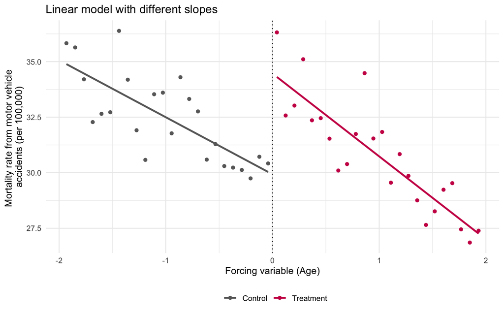

```r
diff_slopes_plot <- mlda_df %>%
  ggplot(aes(x = forcing,
             y = outcome,
             col = factor(treatment))) +
  geom_point() +
  geom_vline(xintercept = 0, linetype = "dotted") +
  geom_smooth(method = "lm", se = F) + # NORMAL SMOOTH
  labs(title = "Linear model with different slopes",
       x = "Forcing variable (Age)",
       y = "Mortality rate from motor vehicle \naccidents (per 100,000)") +
  scale_color_manual(name = "",
                     values = c("#696969", "#cc0055"),
                     labels = c("Control", "Treatment")) + #change colors manually of color argument in aes()
  theme_minimal() +
  theme(legend.position = "bottom")

diff_slopes_plot
```

**Question**

Where can you see our $\beta_0$, $\beta_1$, and $\beta_2$ in the previous plot?

##### Non-linear model (Quadratic model)

Let’s run a quadratic model and plot our results.

**THIS IS HOW WE WOULD FORMALIZE A QUADRATIC MODEL**

$$E(Y_i∣X_i, D_i) = \gamma_0 +
\gamma_1\tilde{X_i} + \gamma_2\tilde{X^2_i} + \tau_3D_i +
\alpha_1\tilde{X_i}D_i + \alpha_2\tilde{X^2_i}D_i$$

We can input this in our regression model as follows:

```r
quadratic <- lm(outcome ~ forcing +
                  I(forcing^2) + # I tells R to interpret "as is"
                  treatment +
                  I(forcing * treatment) +
                  I((forcing^2) * treatment),
                data = mlda_df)

modelsummary::modelsummary(quadratic,
                           stars = c('*' = .1, '**' = .05, '***' = .01),
                           statistic = 'conf.int',
                           fmt = 2)
```

|  | Model 1 |
| --- | --- |
| (Intercept) | 29.81*** |
|  | [28.16, 31.46] |
| forcing | −2.93 |
|  | [−6.80, 0.93] |
| I(forcing^2) | −0.19 |
|  | [−2.08, 1.71] |
| treatment | 4.66*** |
|  | [2.33, 6.99] |
| I(forcing * treatment) | −0.82 |
|  | [−6.29, 4.64] |
| I((forcing^2) * treatment) | 0.20 |
|  | [−2.48, 2.88] |
| Num.Obs. | 48 |
| R2 | 0.722 |
| R2 Adj. | 0.689 |
| AIC | 171.1 |
| BIC | 184.2 |
| Log.Lik. | −78.564 |
| F | 21.864 |
| RMSE | 1.24 |

**WHAT DO THESE RESULTS TELL US?**

In line with our assumptions for non-linear models, we allow our treatment effect $D_i$ to vary along the forcing $X_i$. In this case with quadratic interactions. We can formalize this model as:

$$E(Y_i∣X_i, D_i) = \gamma_0 +
\gamma_1\tilde{X_i} + \gamma_2\tilde{X^2_i} + \tau_3D_i +
\alpha_1\tilde{X_i}D_i + \alpha_2\tilde{X^2_i}D_i$$

Hence we can say, that at given our $\tau$, we can expect 4.66 more deaths from motor vehicle accidents per 100,000 for those who can legally drink at the threshold. We could also calculate the expected value of $Y$ at different levels of $X$.

Say we want to know what the expected value is for 23-year-olds. Since our forcing variable is 0 at 21 years of age, we can think of 23 as 2. Additionally, 23-year-olds are above the legal drinking age minimum, therefore for them the value of $D$ is 1.

$$E(Y | X=2, D =1) = 29.8090 - 2.9330(2)
-0.1852(2)^2 + 4.6629(1) - 0.8231 (2*1) + 0.1985(2*1)^2 = 27.01$$
Based on this, we would expect a mortality rate from motor vehicle accidents of 27.01 per 100,000 for 23-year-olds.

We can graph our results with `ggplot` by extracting the predicted values of our quadratic model to recreate the fit:

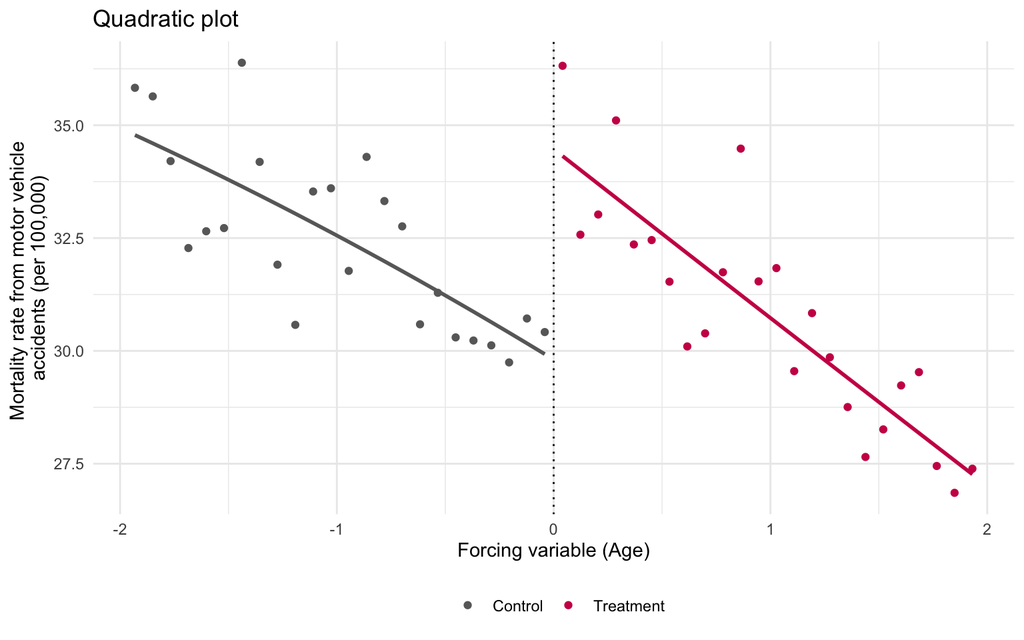

```r
mlda_df$yhat_quadratic <- predict(quadratic)

quadratic_plot <- mlda_df %>%
  ggplot(aes(x = forcing,
             y = yhat_quadratic, #note predicted y
             col = factor(treatment))) +
  geom_point(aes(x = forcing,
                 y = outcome,
                 col = factor(treatment))) +
  geom_vline(xintercept = 0, linetype = "dotted") +
  labs(title = "Quadratic plot",
       x = "Forcing variable (Age)",
       y = "Mortality rate from motor vehicle \naccidents (per 100,000)") +
  geom_line(data = mlda_df[mlda_df$forcing >= 0,],
            color = "#cc0055", # color lines
            linewidth = 1) +
  geom_line(data = mlda_df[mlda_df$forcing < 0,],
            color = "#696969", # color lines
            linewidth = 1) +
  scale_color_manual(name = "",
                     values = c("#696969", "#cc0055"),
                     labels = c("Control", "Treatment")) + #change colors manually of color argument in aes()
  theme_minimal() +
  theme(legend.position = "bottom")

quadratic_plot
```

### Non-parametric estimation

#### Calculating the LATE with `rdrobust()`

`rdrobust()` is part of the `rdrobust` package. It relies on a local polynomial approach to estimation. In non-parametric estimation, we do not specify the functional form, but rather allow the function to perform weigted local linear regressions to either side of the cutpoint using optimal bandwidth calculation. The syntax is the following:

```r
model <- rdrobust::rdrobust(y = outcome,
x = forcing,
c = cutoffvalue,
all = TRUE,
kernel = "tri", #default
bwselect = "mserd",) #default
```

We have the option to set the cutpoint, kernel type, order of the local polynomial, etc.: https://cran.r-project.org/web/packages/rdrobust/rdrobust.pdf

```r
llr <- rdrobust::rdrobust(y = mlda_df$outcome,
                          x = mlda_df$forcing,
                          c = 0,
                          all = TRUE,
                          kernel = "tri",
                          bwselect = "mserd") #

summary(llr, all = TRUE)
```

```
## Sharp RD estimates using local polynomial regression.
##
## Number of Obs.                   48
## BW type                       mserd
## Kernel                   Triangular
## VCE method                       NN
##
## Number of Obs.                   24           24
## Eff. Number of Obs.               6            6
## Order est. (p)                    1            1
## Order bias  (q)                   2            2
## BW est. (h)                   0.487        0.487
## BW bias (b)                   0.738        0.738
## rho (h/b)                     0.660        0.660
## Unique Obs.                      24           24
##
## =============================================================================
##         Method     Coef. Std. Err.         z     P>|z|      [ 95% C.I. ]
## =============================================================================
##   Conventional     4.901     2.059     2.380     0.017     [0.864 , 8.937]
## Bias-Corrected     4.738     2.059     2.301     0.021     [0.702 , 8.775]
##         Robust     4.738     2.518     1.881     0.060    [-0.198 , 9.674]
## =============================================================================
```

**WHAT DO THESE RESULTS TELL US?**

You can see that by setting the model with `all = TRUE` we get three output coefficients. The **Conventional** coefficient performs the weighted local regressions on the data within the optimally selected bandwidth. The **Bias-Corrected** coefficient addresses the inconsistency of selecting the bandwidth according to bias–variance trade-off (MSE), and then proceeding as if bias were zero. Finally, **Robust** coefficient “acknowledges that bias correction (and data-driven, optimal bandwidth choices) have implications for inference” and introduces robust confidence intervals following Calonico et al. (2014).

The general convention in the literature at the moment is to report Robust Bias-Correct (RBC) RD estimates.

In this case, the model is telling us that based on the calculation, the estimated effect would be 4.7 more deaths per 100,000 for those over-21; however, the results are not statistically significant under that specification.

The most straight-forward way to graph the output of this model is through the `rdrobust::rdplot()` function:

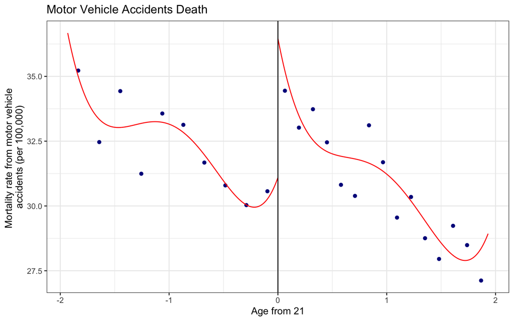

```r
rdrobust::rdplot(mlda_df$outcome,
                 mlda_df$forcing,
                 c = 0,
                 kernel = "tri",
                 title = "Motor Vehicle Accidents Death",
                 x.label = "Age from 21",
                 y.label =  "Mortality rate from motor vehicle \naccidents (per 100,000)"
)
```

## Example 2. Measuring the long term effects of a conditional cash transfer program on educational achievement

Imagine that you work as a technical adviser for the Ministry of Education in your country. You are tasked to assess whether a Conditional Cash Transfer (CCT) program established decades before yields positive results on the beneficiaries’ educational attainment. There is a large amount of evidence which suggests that CCTs encourage households to increase the use of educational services.

You read the guidelines for the program. Families receive a stipend per child provided they keep their them in school and take them for health checks. Additionally, you note that under the rules of the program, beneficiaries are selected based on a household income threshold of €20000. You decide to dive into the data with the idea that a discontinuity is created based on the income threshold. (This example utilizes simulated data)

```r
cct_df <- readr::read_csv("https://raw.githubusercontent.com/seramirezruiz/stats-ii-lab/master/Session%206/data/cct_data.csv") %>% # loading simulated data frame of the program
  dplyr::mutate(hh_income_thousands_centered = (hh_income/1000)-20) # get income in thousands for model and center it
```

The dataset consists of:

- `hh_income`: household income in euros
- `years_of_schooling`: years of schooling for respondent
- `treatment`: binary variable indicating whether respondent was a beneficiary of the program

### Checking visually whether a sharp-RDD makes sense for the analysis

What we are looking for in this case is whether our €20000 threshold is in fact the cut-off for treatment. That is to say, that only those who had a household income of equal or less than €20000 received the cash transfer.

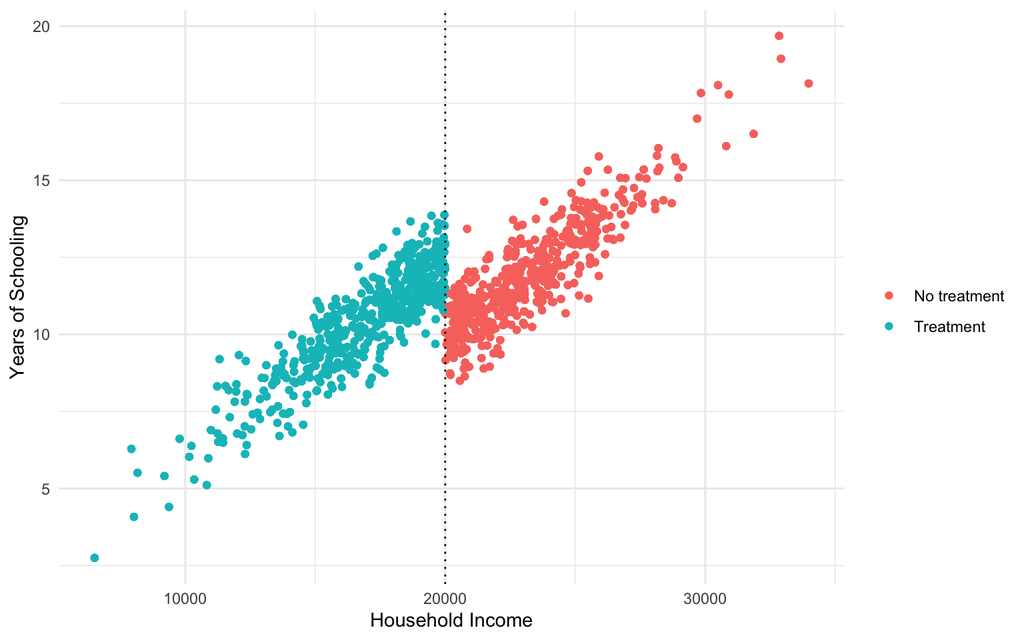

```r
ggplot(cct_df,
       aes(x = hh_income,
           y = years_of_schooling,
           color = factor(treatment))) +
  geom_point() +
  labs(x = "Household Income",
       y = "Years of Schooling") +
  scale_color_discrete(name = " ",
                       labels = c("No treatment", "Treatment")) +
  geom_vline(xintercept = 20000, linetype = "dotted") +
  theme_minimal()
```

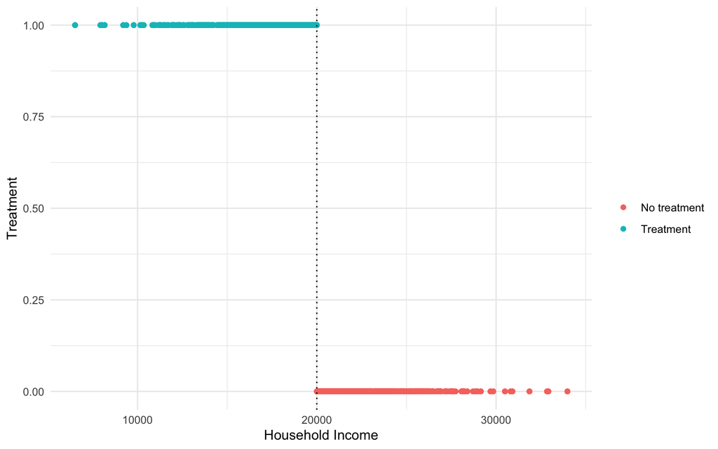

```r
ggplot(cct_df,
       aes(x = hh_income,
           y = treatment,
           color = factor(treatment))) +
  geom_point() +
  labs(x = "Household Income",
       y = "Treatment") +
  scale_color_discrete(name = " ",
                       labels = c("No treatment", "Treatment")) +
  geom_vline(xintercept = 20000, linetype = "dotted") +
  theme_minimal()
```

We can see from the graph that our €20000 threshold is in fact cutting off the distribution of the treatment. This would make household income a viable forcing variable for a sharp-RDD set-up.

### Estimating our models

#### Linear model

We can see that the relationship is fairly linear, so we decide to run a linear model with common slope.

```r
# running linear model with common slope
ed_achievement <- lm(years_of_schooling ~ treatment + hh_income_thousands_centered, data = cct_df)

modelsummary::modelsummary(list("Linear Common Slope"= ed_achievement),
                           stars = c('*' = .1, '**' = .05, '***' = .01),
                           gof_omit = "AIC|BIC|Log.Lik.",
                           statistic = 'conf.int', fmt = 2)
```

|  | Linear Common Slope |
| --- | --- |
| (Intercept) | 9.90*** |
|  | [9.86, 9.94] |
| treatment | 2.46*** |
|  | [2.39, 2.53] |
| hh_income_thousands_centered | 0.63*** |
|  | [0.62, 0.64] |
| Num.Obs. | 5000 |
| R2 | 0.815 |
| R2 Adj. | 0.815 |
| F | 11008.946 |
| RMSE | 0.82 |

**WHAT DO THESE RESULTS TELL US?**

In line with our assumptions for linear models with common slope, we consider that treatment effect, $D_i$, does not vary across the forcing $X_i$. Hence, we can expect that students who received the treatment get on average 2.46 more years of schooling. We also see that for every €1,000 increase in the household income, students are expected to attain 0.63 more years of education. (Our $\beta = .63*1$).

**Getting familiar with LOESS**

Locally weighted smoothing is a popular tool used in regression analysis that creates a smooth line through a scatter plot to help you to see relationship between variables and foresee trends. We can introduce it to our `ggplot()` as a part of geom_smooth by calling method “loess”.

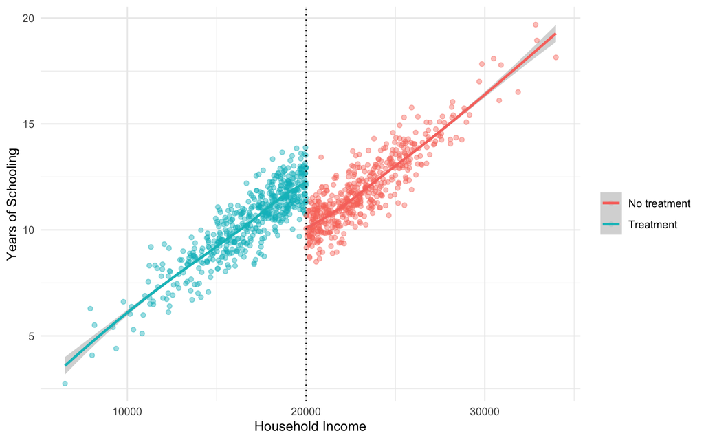

```r
ggplot(cct_df,
       aes(x = hh_income,
           y = years_of_schooling,
           color = factor(treatment))) +
  geom_point(alpha = 0.1) +
  labs(x = "Household Income",
       y = "Years of Schooling") +
  geom_smooth(method = "loess") + # instead of lm, we use loess. See the difference? try with lm
  scale_color_discrete(name = " ",
                       labels = c("No treatment", "Treatment")) +
  geom_vline(xintercept = 20000, linetype = "dotted") +
  theme_minimal()
```

The LOESS smoothing is not very visible in this relationship because of the way we defined the simulated data. Let’s look at how it would look in our drinking age example:

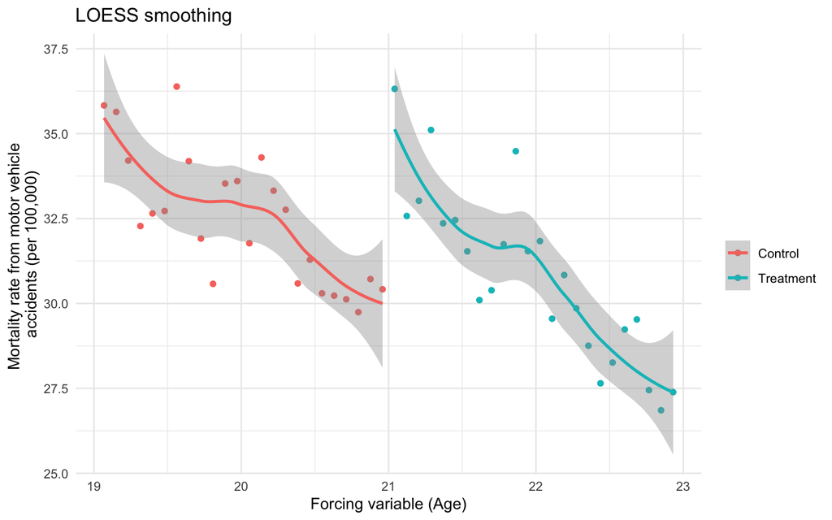

```r
ggplot(mlda_df,
       aes(x = agecell,
           y = outcome,
           col = factor(treatment))) +
  geom_point() +
  geom_smooth(method = "loess") +
  labs(title = "LOESS smoothing",
       x = "Forcing variable (Age)",
       y = "Mortality rate from motor vehicle \naccidents (per 100,000)") +
  scale_color_manual(name = "",
                     values = c("#F8766D", "#00BFC4"),
                     labels = c("Control", "Treatment")) +
  theme_minimal()
```

#### Violations to the assumptions

You are made aware by a tax expert from your unit that €20000 is the upper-boundary for a very well known tax concession. You are afraid that people may be sorting themselves before the household income cut-off to become beneficiaries of multiple programs. You decide to check your data.

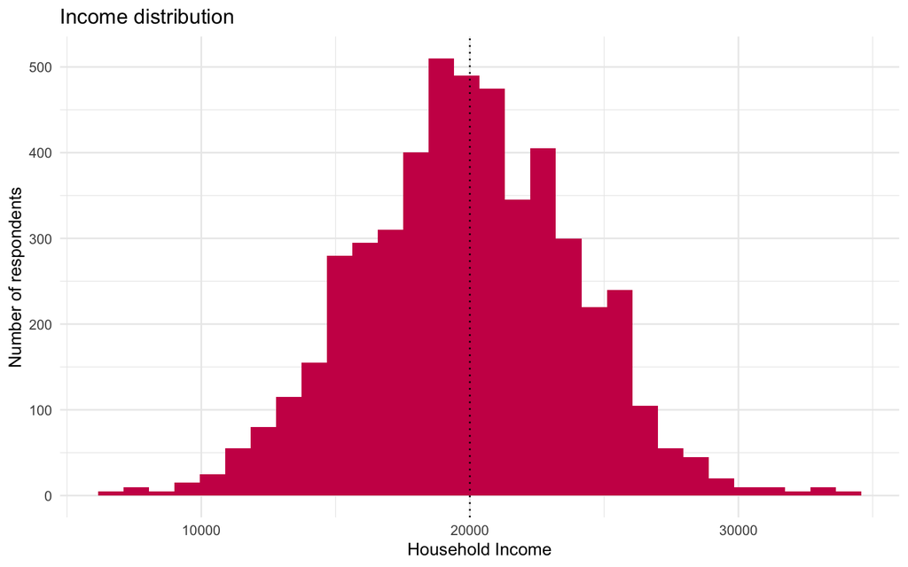

```r
ggplot(cct_df,
       aes(x = hh_income)) +
  geom_histogram(fill = "#cc0055") +
  labs(title = "Income distribution",
       x = "Household Income",
       y = "Number of respondents") +
  geom_vline(xintercept = 20000, linetype = "dotted") +
  theme_minimal()
```

This case looks a bit ambiguous. Do you think people are sorting out just before the cut-off? If sorting were to exist which assumptions would be challenged? Would the existence of other programs that have the same threshold affect a causal reading of our results?

There are a couple of tests researchers can employ. We will learn two ways. First, a method by which the research chooses a window of sorting to check if the distribution could have occurred by chance and second the McCrary test you met in Cunningham (2021).

#### Binomial test

When we apply an exact binomial test. Our interest is to see whether the distribution around the threshold could exist by chance. In this case, let’s check ±500 around the threshold.

`dplyr::between()` is a shortcut for `x >= left & x <= right`. Let’s look at it at work.

```r
cct_df %>%
  dplyr::filter(dplyr::between(hh_income, 19500, 20500)) %>% #filter values between 19500 and 21500
  dplyr::group_by(treatment) %>%
  dplyr::summarize(n = n()) %>%
  knitr::kable() %>%
  kableExtra::kable_styling()
```

| treatment | n |
| --- | --- |
| 0 | 255 |
| 1 | 300 |

```r
binom.test(one_of_the_n, total_n, p = probability_of_success)
```

Let’s see:

```r
binom.test(300, 555, p = 0.5)
```

```
##
##  Exact binomial test
##
## data:  300 and 555
## number of successes = 300, number of trials = 555, p-value = 0.06171
## alternative hypothesis: true probability of success is not equal to 0.5
## 95 percent confidence interval:
##  0.4980565 0.5825909
## sample estimates:
## probability of success
##              0.5405405
```

**WHAT DO THESE RESULTS TELL US?**

According to the test, we see that the observed distributions **do not deviate** from expected distribution of observations into the two categories when we expect that units just around the threshold end up on either group by chance (coin flip logic, i.e., p = 0.5). In other words, this results present no evidence of sorting.

How about ±250?:

```r
binom.test(115, 290, p = 0.5)
```

```
##
##  Exact binomial test
##
## data:  115 and 290
## number of successes = 115, number of trials = 290, p-value = 0.0005095
## alternative hypothesis: true probability of success is not equal to 0.5
## 95 percent confidence interval:
##  0.3398404 0.4553997
## sample estimates:
## probability of success
##              0.3965517
```

**WHAT DO THESE RESULTS TELL US?**

According to the test, we see that the observed distributions **deviate** from expected distribution of observations into the two categories when we expect that units just around the threshold end up on either group by chance (coin flip logic, i.e., p = 0.5). In other words, this results present some evidence of sorting in this window.

#### McCrary Sorting test

An alternative way to check for self-sorting is the McCrary Sorting test. In this test, the discretion on window selection is taken away from the researcher (at least in the defaults). The McCrary Sorting test is included in the `rdd` package. This is the syntax of the test:

```
rdd::Dcdensity(runvar=running_variable, cutpoint=cutpoint)
```

Let’s see it in practice:

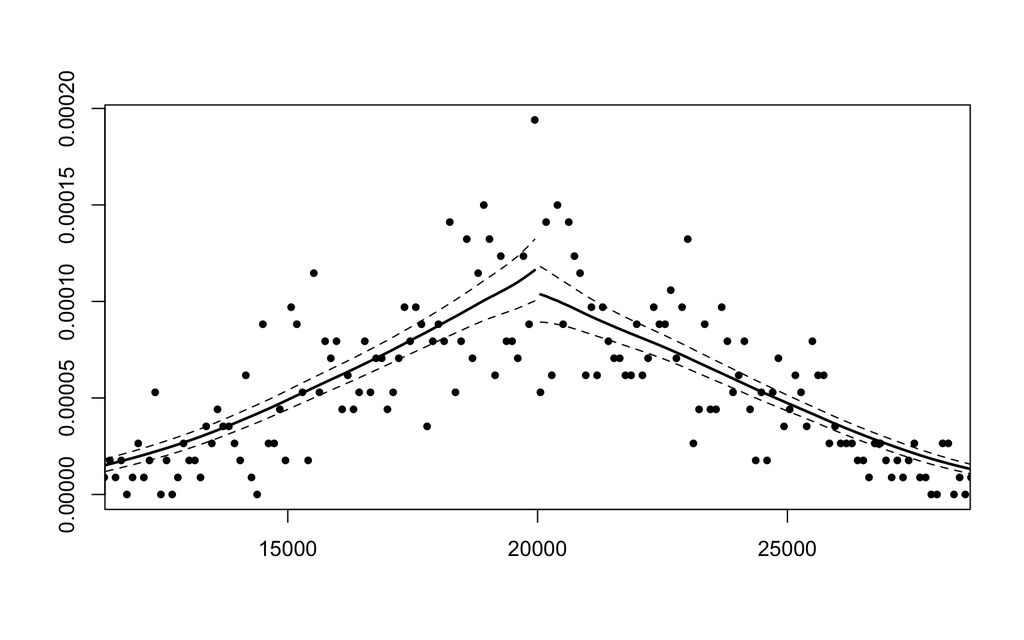

```
## [1] 0.04168422
```

```r
rdd::DCdensity(cct_df$hh_income, cutpoint = 20000)
```

**WHAT DO THESE RESULTS TELL US?**

The default output is a p-value of the test. A p-value below the significance threshold indicates that the user can reject the null hypothesis of no sorting. In other words, this test would suggest (p = 0.04) that our observed distributions **deviate** from the expected distribution of observations. This results present some evidence of sorting.

# **Acknowledgements**

This script was drafted by [Lisa Oswald](https://lfoswald.github.io/) and [Sebastian Ramirez-Ruiz](https://seramirezruiz.github.io/), with contributions by [Adelaida Barrera Daza](https://www.linkedin.com/in/adelaidabarrera/), [Carolina Díaz Suárez](https://www.linkedin.com/in/carolinadiazsuarez/), [Sofía García-Durrer](https://www.linkedin.com/in/sofia-garcia-durrer/), and [William Fernandez](https://www.hertie-school.org/en/who-we-are/profile/person/tinoco).